# Lecture 22: Steady-state behavior, Absorption

Jamie Haddock

# Steady-State Behavior

We are often interested in the long-term occupancy behavior in Markov models. In particular, we’ll be interested in the long-term behavior of the $n$-step transition probabilities
$$r_{ij}(n) \;=\; P(X_n = j \mid X_0 = i) \qquad \text{as } n \to \infty .$$

- After many steps, does the chain “settle down”?
- Does it matter **where we started** ($i$)?

We’ll see that $r_{ij}(n) \to \pi_j \approx P(X_n = j),$ the *steady-state probability of $j$*.

## Motivating Example: Machine Working/Broken

Recall our example from the prior lecture: each day a machine is either **working** (state 1) or **broken** (state 2).

- If working today, it breaks down tomorrow with probability $b$.
- If broken today, it is repaired tomorrow with probability $r$.

$$P = \begin{bmatrix} 1-b & b \\ r & 1-r \end{bmatrix}$$

For numerical calculations in this example, we’ll use $b = 0.1$ and $r = 0.5$.

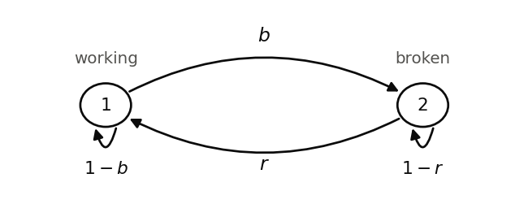

## Example: Machine Working/Broken

Chapman–Kolmogorov: we can compute the the matrix with $i,j$th entry $r_{ij}(n)$ as the matrix power $P^n$.

```
 n  r11(n)  r12(n)  r21(n)  r22(n)
 1  0.9000  0.1000  0.5000  0.5000
 5  0.8350  0.1650  0.8248  0.1752
10  0.8334  0.1666  0.8332  0.1668
20  0.8333  0.1667  0.8333  0.1667
```

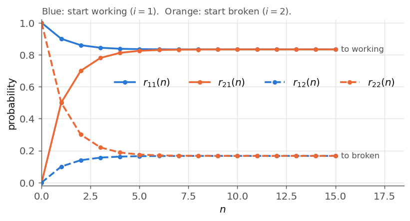

## Steady-State Convergence

**Theorem (Steady-state convergence)**

Consider a Markov chain with a **single recurrent class** which is **aperiodic**. Then, the states $j$ are associated with **steady-state probabilities** $\pi_j$ that have the following properties.

1. For every state $j$, we have
   $$\pi_j = \lim_{n \to \infty} r_{ij}(n)$$
   for all $i$.
2. The $\pi_j$ are the unique solution of the **balance equations** and the **normalization equation**:
   $$\pi_j = \sum_{k=1}^m \pi_k p_{kj}, \quad j = 1, \dots, m, \qquad\qquad \sum_{j=1}^m \pi_j = 1 .$$
3. $\pi_j = 0$ if $j$ is transient, and $\pi_j > 0$ if $j$ is recurrent.

### Why each assumption is necessary

- *Single recurrent class.* If there are several recurrent classes, where the chain ends up depends on where it starts, so the limit **depends on $i$**.
- *Aperiodic.* If the recurrent class is periodic, the chain cycles deterministically through groups of states and $r_{ij}(n)$ **has no limit**.

## Stationary Distribution

**Definition (Stationary distribution)**

A probability distribution $\pi = (\pi_1, \dots, \pi_m)$ on the states is **stationary** if it satisfies the **balance equations**
$$\pi_j = \sum_{k=1}^m \pi_k \, p_{kj}, \qquad j = 1, \dots, m.$$

**Why “stationary”?** If $P(X_0 = j) = \pi_j$ for all $j$, then
$$P(X_1 = j) = \sum_k P(X_0 = k)\, p_{kj} = \sum_k \pi_k p_{kj} = \pi_j ,$$
and by induction $X_n \sim \pi$ for **every** $n$: the distribution no longer changes.

## Stationary Distribution

**Balance equations:**

Recall the Chapman–Kolmogorov equation:
$$r_{ij}(n) = \sum_{k=1}^m r_{ik}(n-1)\, p_{kj} .$$

Let $n \to \infty$. Under the assumptions of the theorem, $r_{ij}(n) \to \pi_j$ and $r_{ik}(n-1) \to \pi_k$, and the sum is **finite**, so the limit passes through it:
$$\pi_j = \sum_{k=1}^m \pi_k \, p_{kj} . \qquad\blacksquare$$

The steady-state probabilities satisfy $\pi = \pi \mathbf{P}$, i.e. $\pi$ is a left eigenvector of $\mathbf{P}$ with eigenvalue $1$. A very famous theorem, the Perron-Frobenius theorem in linear algebra guarantees that such a vector will exist for any transition probability matrix $\mathbf{P}$ whose Markov chain satisfies the assumptions in the prior theorem.

### Example: Machine Working/Broken

Balance equations (with $\pi_1$ = working, $\pi_2$ = broken):
$$\pi_1 = (1-b)\,\pi_1 + r\,\pi_2 , \qquad \pi_2 = b\,\pi_1 + (1-r)\,\pi_2 .$$

Both reduce to the **same** equation $b\,\pi_1 = r\,\pi_2$. Use normalization $\pi_1 + \pi_2 = 1:$
$$\pi_1 = \frac{r}{b + r}, \qquad \pi_2 = \frac{b}{b + r} .$$

With $b = 0.1$, $r = 0.5$: $\;\pi = \left(\tfrac56, \tfrac16\right) \approx (0.8333,\, 0.1667)$.

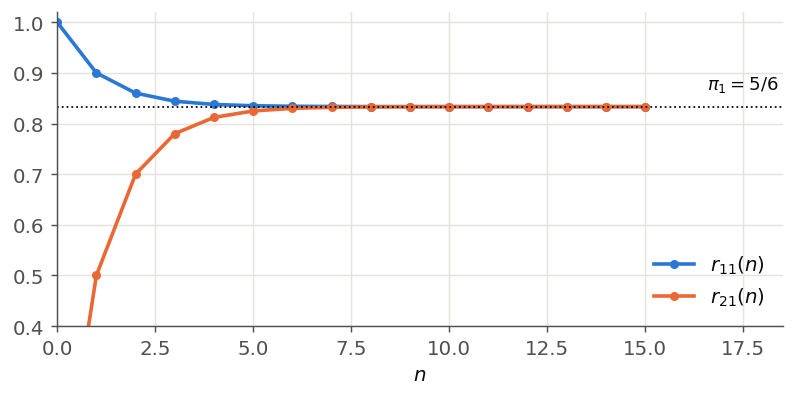

## Long-Term Frequency Interpretation

Let $v_{ij}(n)$ be the expected number of visits to $j$ in the first $n$ transitions, starting from $i$:
$$v_{ij}(n) = E\big[|\{k \le n : X_k = j\}| \mid X_0 = i\big] = \sum_{k=1}^n r_{ij}(k).$$

If $r_{ij}(k) \to \pi_j$, then the *average* of the first $n$ terms converges to the same limit:
$$\frac{v_{ij}(n)}{n} \;\longrightarrow\; \pi_j \qquad (n \to \infty).$$

**$\pi_j$ is the long-run expected fraction of time the chain spends in state $j$**, whatever the starting state.

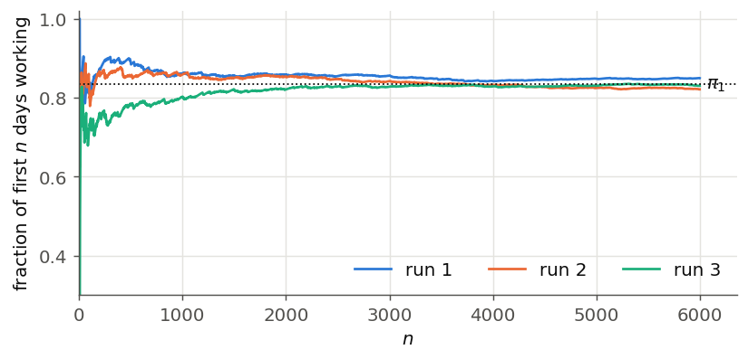

### Balance equations

If $\pi_j$ is the fraction of time at $j$, then the number of visits to $j$ is the **sum of the numbers of visits to neighbors that transition to $j$**: each visit to $k$ is followed by a jump to $j$ with probability $p_{kj}$. So transitions $k \to j$ occur with frequency $\pi_k\, p_{kj}$, and
$$\boxed{\;\pi_j = \sum_{k} \pi_k\, p_{kj}\;}$$

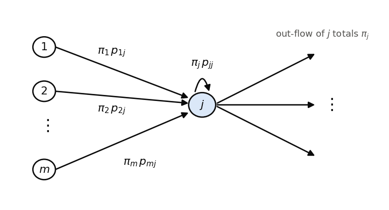

# Absorption

**Definition.** A state $s$ is **absorbing** if $p_{ss} = 1$: once the chain enters $s$ it never leaves. An absorbing state is a recurrent class by itself.

Recall the classification of Markov chain behavior:

- The chain visits each of the transient states at most a finite number of times initially.
- With probability $1$, the chain eventually leaves the transient states **for good** and enters a recurrent class, where it remains **forever** and visits its states **infinitely often**.
- This is **absorption**.

Two natural questions: **which** recurrent class (absorbing state) does it end up in, and **how long** does it take?

## Absorption Probability Equations

Fix an absorbing state $s$. Define the **absorption probability**
$$a_i = P(X_n \text{ eventually equals } s \mid X_0 = i) .$$

**Absorption probability equations**

Consider a Markov chain where each state is either transient or absorbing, and fix a particular absorbing state $s$. Then the probabilities $a_i$ of eventually reaching state $s$, starting from $i$, are the unique solution to the equations
$$a_s = 1, \\a_i = 0 \;\text{ for every absorbing } i \ne s, \\a_i = \sum_{j=1}^m p_{ij}\, a_j \;\text{ for every transient } i .$$

This system has a **unique solution**.

### Example: Gambler’s Ruin

A gambler starts with $\$i$ and plays rounds, winning $\$1$ with probability $p$ and losing $\$1$ with probability $q = 1-p$, independently. She stops when she reaches $\$m$ (target) or $\$0$ (ruin).

**Question:** what is the probability she reaches $\$m$ before going broke?

This is a Markov chain on $\{0, 1, \dots, m\}$ with $p_{i,i+1} = p$, $\;p_{i,i-1} = q$ for $0 < i < m$, and $p_{00} = p_{mm} = 1$.

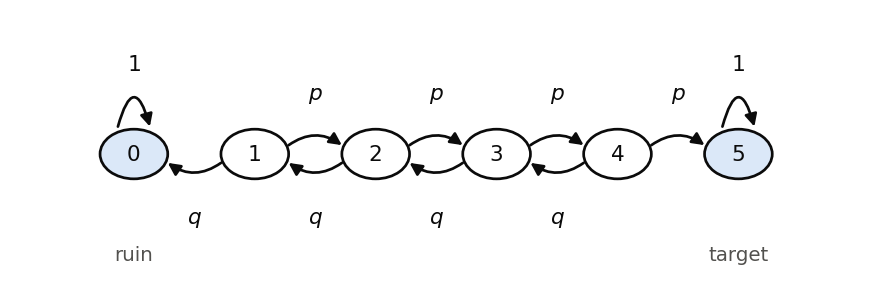

**Transient and recurrent states**

- States $0$ and $m$ are **absorbing**, so each is a **recurrent class** by itself.
- States $1, \dots, m-1$ are **transient**: from each, there is a positive probability of reaching $0$ or $m$ (which can never come back).
- There are finitely many transient states, so the gambler is **absorbed** with probability $1$: she either reaches the target or goes broke (the game ends).

Fix $s = m$ and let $a_i$ be the probability that the gambler reaches $m$ beginning from state $i$.

**Calculate the absorption probabilities** (absorbing state $s = m$)

$$a_0 = 0, \qquad a_m = 1, \qquad a_i = p\,a_{i+1} + q\,a_{i-1}, \quad 0 < i < m.$$

Write $a_i = (p+q)\,a_i$ and rearrange:
$$a_{i+1} - a_i = \rho\,(a_i - a_{i-1}), \qquad \rho = \frac{q}{p}.$$

Since $a_0 = 0$: $\;a_{i+1} - a_i = \rho^{i}\, a_1$. Summing,
$$a_i = a_1\,(1 + \rho + \dots + \rho^{i-1}).$$

Use $a_m = 1$ to find $a_1 = 1/(1 + \rho + \dots + \rho^{m-1})$.

$$\boxed{\; a_i = \begin{cases} \dfrac{1 - \rho^{\,i}}{1 - \rho^{\,m}}, & p \ne \tfrac12 \quad (\rho = q/p),\\[3mm] \dfrac{i}{m}, & p = \tfrac12 . \end{cases}}$$

Check: $a_0 = 0$ and $a_m = 1$.

**The dependence on $p$ and $m$:**

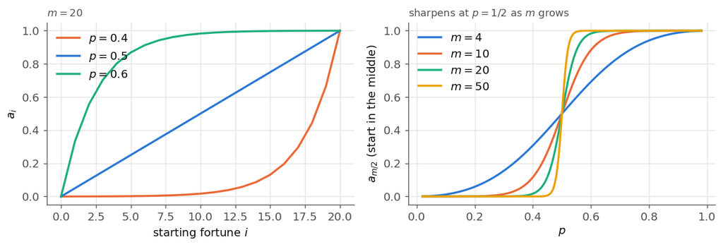

## Expected Time to Absorption

**Definition.** Starting from state $i$, let
$$\mu_i = E[\text{number of transitions until absorption starting from } i] \\= E[\min\{n \ge 0 \mid X_n \text{ is recurrent}\} \mid X_0 = i].$$

**Equations for the expected time to absorption**

The expected times to absorption, $\mu_1, \cdots, \mu_m$, are the unique solution to the equations
$$\mu_i = 0 \;\text{ for every recurrent } i, \\ \mu_i = 1 + \sum_{j=1}^m p_{ij}\,\mu_j \;\text{ for every transient } i .$$

*Why?* One transition is used (the “$1$”) to leave $i$, then the chain is at $j$ with probability $p_{ij}$ and needs $\mu_j$ more transitions on average.

### Example: Gambler’s Ruin

```python
p, m, i0 = 0.45, 10, 5
mu = hitting_times(gamblers_P(m, p), targets={0, m})
#print("linear system mu_5 :", round(mu[i0], 3))
#print("closed form  mu_5 :", round(duration_closed(i0, m, p), 3))
#print("fair game closed form i(m-i) at i=5:", duration_closed(5, 10, 0.5))

N = 200_000
pos = np.full(N, i0); steps = np.zeros(N, dtype=int); active = np.ones(N, dtype=bool)
while active.any():
    move = np.where(rng.random(N) < p, 1, -1)
    pos[active] += move[active]; steps[active] += 1
    active = (pos > 0) & (pos < m)
#print("simulation mean    :", round(steps.mean(), 3))
```

[figure not shown]

# Mean Passage + Recurrence

For simplicity we now consider a chain with a **single recurrent class** and fix a recurrent state $s$.

**Mean first passage time** to $s$ from $i$:
$$t_i = E\big[\min\{n \ge 0 : X_n = s\} \mid X_0 = i\big] .$$

**Mean recurrence time** of $s$:
$$t_s^* = E\big[\min\{n \ge 1 : X_n = s\} \mid X_0 = s\big] .$$

# Mean Passage + Recurrence

**Equations for mean first passage and recurrence times**

The mean first passage time values satisfy
$$t_s = 0, \qquad t_i = 1 + \sum_{j=1}^m p_{ij}\, t_j \;\;\text{ for } i \ne s ,$$
and the mean recurrence time is related to the first passage times as
$$t_s^* = 1 + \sum_{j=1}^m p_{sj}\, t_j .$$

### Example: broken/working machine

Mean first passage time:

Target state $s = 1$ (working). From broken (state 2):
$$t_2 = 1 + (1 - r)\,t_2 + r\,t_1 \;\Longrightarrow\; t_2 = \frac1r.$$

This is the expectation of a geometric RV!

Mean recurrence time of “working”:
$$t_1^* = 1 + (1-b)\,t_1 + b\,t_2 = 1 + \frac{b}{r} = \frac{b + r}{r} = \frac{1}{\pi_1}.$$